# CSUF-Math536 Statistical Consultancy

DARPA Report

Analyst: Seth Arreola

3/11/2022

[figure not shown]

### Introduction

This analysis is conducted at the request of The Defense Advanced Research Projects Agency (DARPA). The DARPA are primarily interested in the analysis of their **air-to-air missile deference program**. The air-to-air defense program eliminates hostile flying objects in protected airspace via missile interception. Interceptors estimate the position of the hostile object and tracks distance between itself and the object. This estimation needs to be computed as accurately as possible for successful interception to occur however currently the program estimates position with some error. The primary goal of this report is to analysis this error and investigate it with respect to the distance between the missile and the object. Specifically, we will determine the average error will be at 0.1, 1 and 10 km respectively as per request by DARPA.

### The Data

For testing DARPA’s missile interceptors drones were used to simulate hostile flying objects. The drones themselves provide precise information on their location. Therefor the data provided by DARPA contains two variables.

- The actual distance (km) between the missile and the test drone.
- The error (m) in the estimated position of the drone by the missile and the true position of the drone.

| Distance (km) | Error (m) |
| --- | --- |
| 1.0e-07 | -0.1246386 |
| 3.0e-07 | 0.0175690 |
| 5.0e-07 | -0.4409281 |
| 8.0e-07 | 0.2613991 |
| 1.2e-06 | -0.1952263 |
| 1.8e-06 | -0.6575580 |

In Order to get a sense of the entier dataset and the relationship between these variables, Distance and Error are plotted together here:

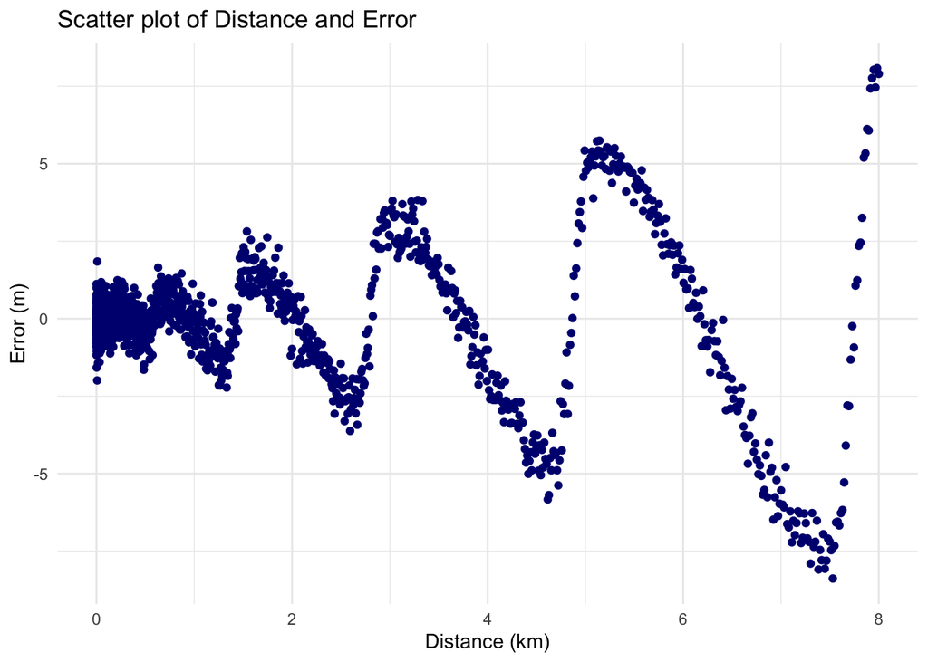

Notice, we can see oscillating behavior in Error which increases as Distance increases. It makes reasonable sense that the farther apart the drone and the missile are, the larger the error will be on average. However, this osculation is an interesting trend which may be due adjustments in flight to the perceived position of the drone, more information on the missiles flight logistics and data would be needed to explore this phenomenon further.

##### Distiance

After taking a brief look at the first few rows of our data above, and also from the scatter plot, we can see that we have some very small values for distance, taking a closer look at the “distance” variable:

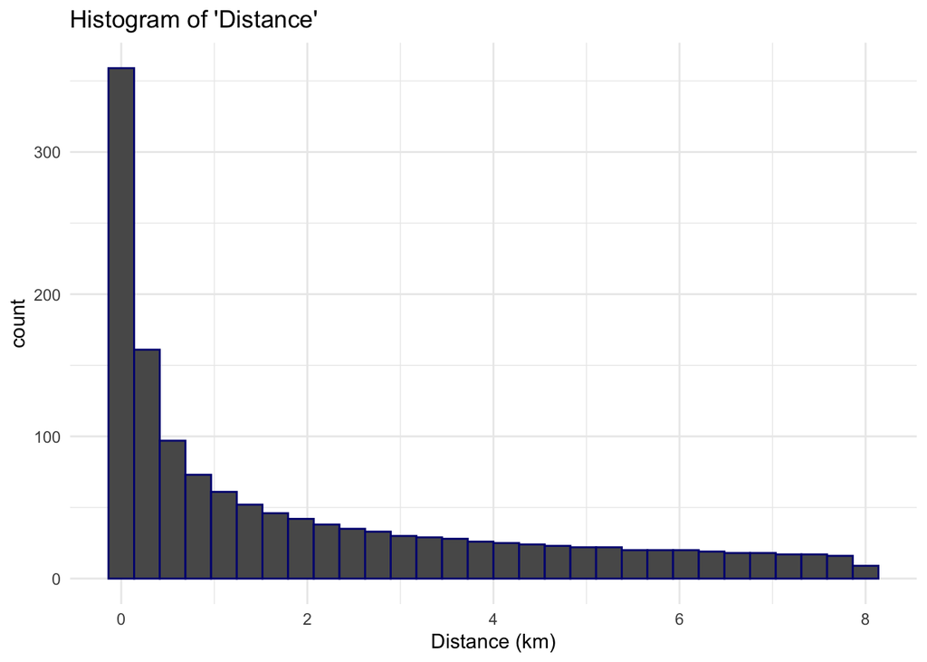

##### Error

Lets now take a look at the error variable in the data

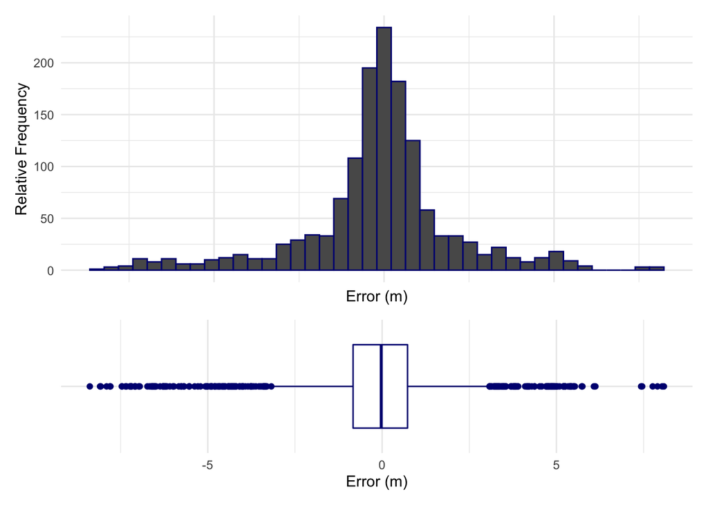

We can see that most of the error is near zero, 50% of the data is within 0.781198 units from zero. From the scatter plot above, we know that many of these observations occurred when the distance of the missile to the drone was very small.

### Statistical Methodology

As we have been prompted to estimate the average error in drone position given fixed distances between the done and missile, prediction accuracy and reliability is of utmost importance in the following modeling. With this goal in mind, multiple statistical models were developed, trained, and tested in an comprehensive search for the optimal model to give predictions/estimates. The two statistical frameworks used to build the following models are Simple Linear Regression and Kernel Regression. Note, that the data was split into training and testing data, where all training, model tuning, and model selection were done on the training data and the testing data was used to generate an unbiased estimate of the performance of the entire modeling procedure.

#### Feature Engineering and Parameter Tuning

Kernel Regression did not require any changes to the data for modeling, but it did require parameter turning. The parameter “Bandwidth” which defines the standard-deviation of individual kernels is a hyper-parameter, and needs to be selected prior to fitting.

- Bandwidth was selected via 10-fold cross validation were the value is found by optimization with respect to sum of squared residuals in each iteration.

Linear regression required multiple transformations of the data in order to satisfy these assumptions and prep the data for modeling. These multiple transformations were tested in a systematic fashion and results were analyzed via diagnostic plots. The final transformations on the data for linear regression were:

- Hyperbolic transformation of the response variable (Error) in order to reduce the non-constant variance of the base SLR model
- Power transformation of the predictor variable (Distance) in order to improve linearity which was broken after the first transformation

The resulting diagnostic plot can be viewed in the appendix. **Note,** the assumption of residual normality was broken after the above transformations, thus if any inference on the SLR model were to occur, bootstrapping methods would be applied.

#### Model Selection

Root Mean Squared Error and $R^2$ were used as an objective measures of fit for selecting the final model. These metrics were computed via 10-fold cross validation. For each iteration of this cross validation process the necessary parameter were tuned and transformed using only the training data for that iteration. The resulting averaged results from this process can be viewed bellow:

| lm_cv_avg_rmse | lm_cv_avg_rsq | kr_cv_avg_rmse | kr_cv_avg_rsq |
| --- | --- | --- | --- |
| 0.6290781 | -0.0172347 | 0.5460296 | 0.9407844 |

Unsurprisingly, the non-parametric Kernel regression model performed far better than the linear regression model. Therefor, Kernel regression with a bandwidth selected via 10-fold cross-validation was chosen as the finalized model to generate estimates/predictions. The linear regression model performed quite poorly, please see the appendix for a brief discussion on its performance.

Note that the finalized model was then tested once more with the initial held-out test set to exhaustively estimate performance, the results were very similar to the cross validated results.

| root_mean_sq_error | r_squared |
| --- | --- |
| 0.5128716 | 0.9386701 |

In order to generate confidence and prediction intervals from our finalized Kernel Regression model a bootstrapping protocol was implemented. For this to be a valid technique, we ensure that the finalized model produces residuals with constant variance with the plot below:

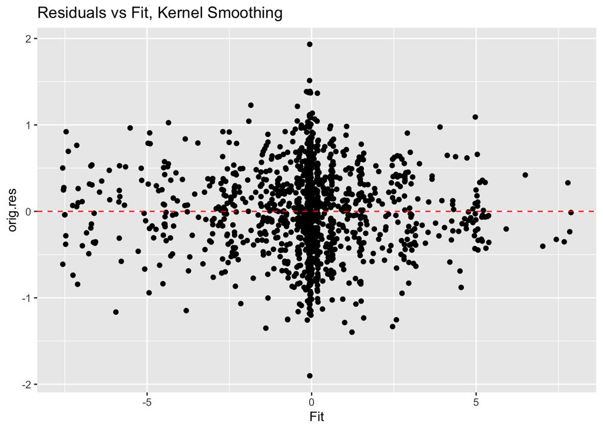

### Results and Conclusion

Using the finalized model from the modeling process described above we can now visualize the data (Distance and Error) with the estimated expected value of error given distance with the Kernel Regression model:

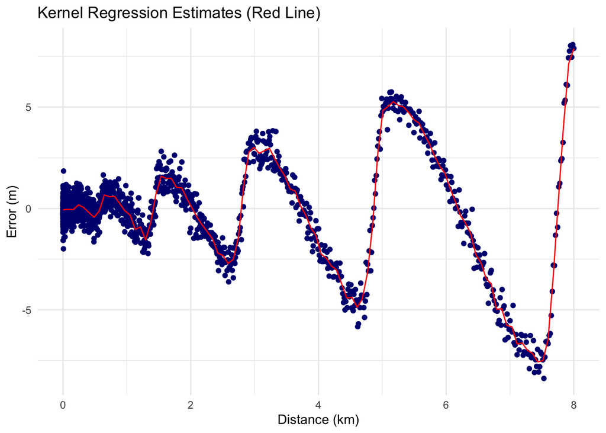

For the distance values of 0.1 and 1, an estimate of the average error was computed along with a 95% confidence interval for this average error. Note that these intervals were created via bootstrapping.

| Distance | Estimate | Lower_Bound | Upper_bound |
| --- | --- | --- | --- |
| 0.1 | -0.0722451 | -0.1606864 | 0.0180664 |
| 1.0 | -0.1825071 | -0.3849238 | 0.0131997 |

These results can be visualized here:

- Note that a 95% prediction interval (we can be 95% confident that a randomly selected observation at this distance will fall within this range) was added.
- The 95% confidence interval for the **Average** is visualized at the gold line while the prediction interval is the dashed red line.
- This plot is zoomed-in to only show observations for distances up to 2 (km).

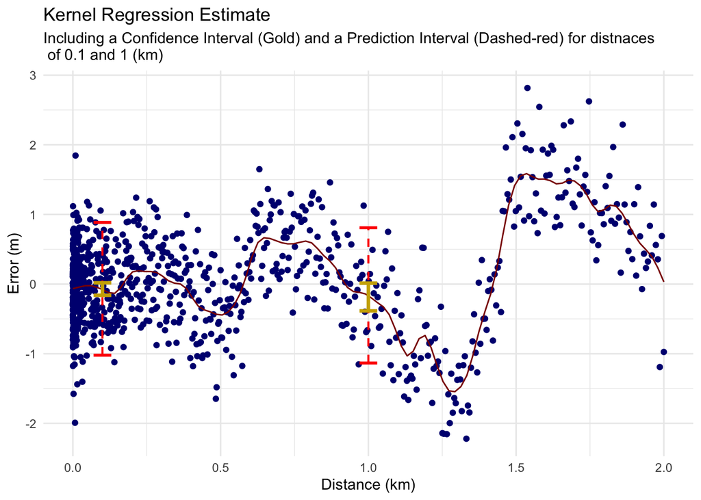

Since we cannot estimate the value for 10 km we instead provide an estimate and confidence interval for 8 km:

| Distance | Estimate | Lower_bound | Upper_bound |
| --- | --- | --- | --- |
| 8 | 7.803823 | 7.114465 | 8.402561 |

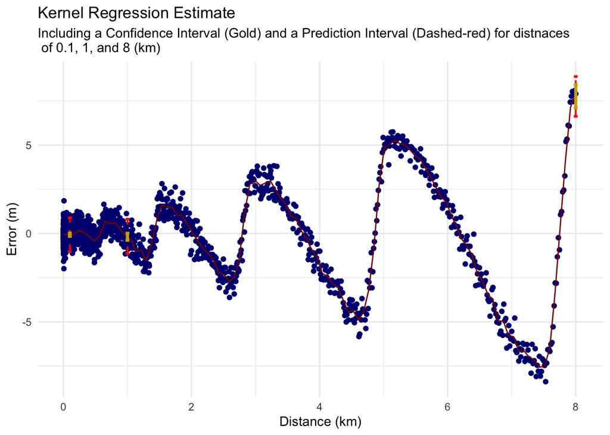

### Future Work

Through this analysis, two interesting observations were make that required further analysis. Firstly, we noticed some osculating behavior in the error of the location estimation by the missiles. To completely understand this phenomenon more information and data on the logistics of the missiles flight path, method of location estimation, and time intervals of estimation occurrence would be needed, Secondly, in order to model and then give statistically sound estimates of the average error at 10 km more data would be needed to train the model, specifically observations of missiles between 8 (km) and 11 (km) would be ideal.

### Appendix

**Code:**

- Code for the entire analysis procedure is available upon request
- Code only pertaining to the modeling pipeline/workflow is available upon request

**Diagnostic plot for linear regression**

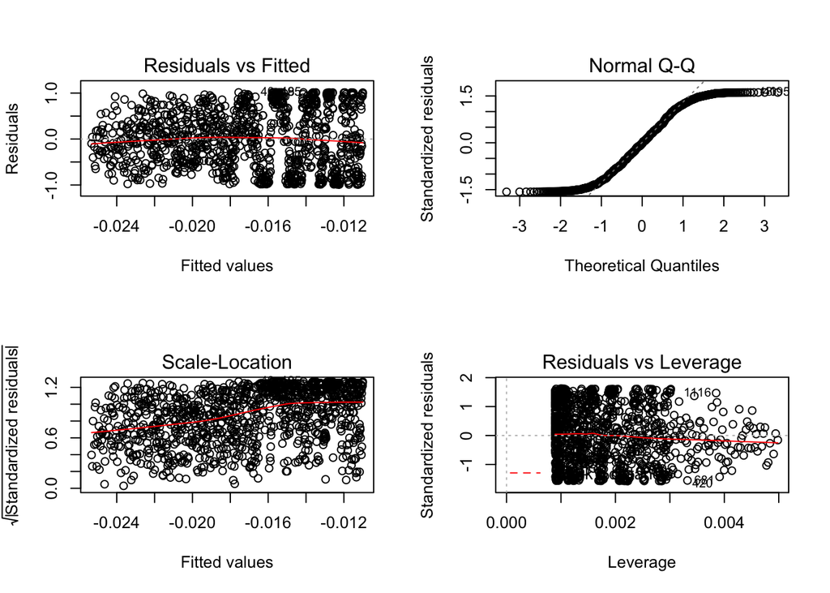

**Plot of Linear Model:**

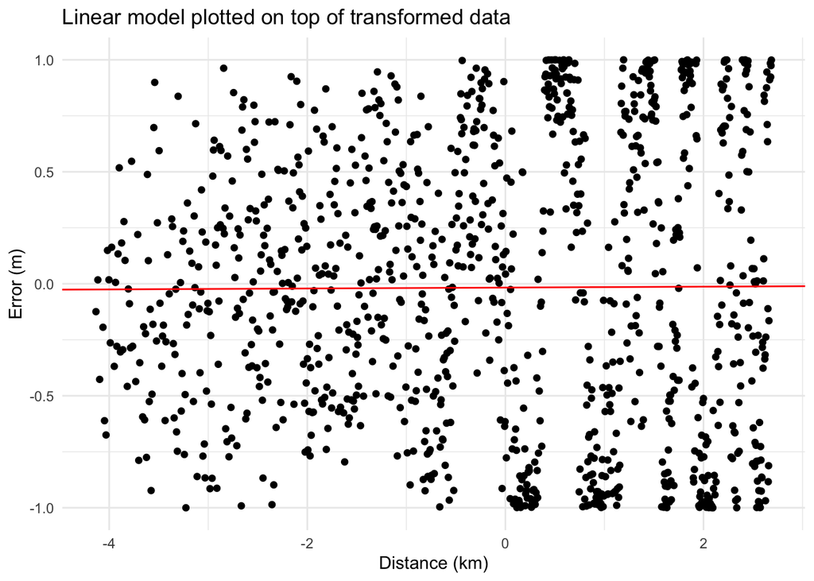

Here we can now see why the $R^2$ value is so low, for this model the cross-validated $R^2\approx 0$, which would suggest that the model and a horizontal line would explain the data equally well.